# cschmidt-quant_assignment3

cschmidt

9/23/2020

#Intro Filter for Use

```r
library(dplyr)
```

```r
library(ggplot2)
df<-read.csv("assignment1.csv")
df2<-filter(df, weeklyhoursworked >= 0, salary >= 0, totalmarriages >= 0)
head(df2)
```

```
##                         maritalstatus weeklyhoursworked salary children
## 1                            Divorced                 0      0        0
## 2 Never married or under 15 years old                 0      0        0
## 3 Never married or under 15 years old                40  23000        0
## 4 Never married or under 15 years old                35  43800        0
## 5                           Separated                 0      0        0
## 6 Never married or under 15 years old                40  19000        2
##   totalmarriages
## 1              2
## 2              0
## 3              0
## 4              0
## 5              1
## 6              0
```

Enumeration of Variable Types:

maritalstatus: categorical variable with three or more levels (5) children: categorical variable with three or more levels (3) total marriages: continuous variable (at least by original classification) salary: continuous variable weeklyhoursworked: continuous variable

Combos: salary/weeklyhoursworked: Pearson’s Correlation (Significance & Correlation) maritalstatus OR children/salary OR weeklyhoursworked: ANOVA (Correlation) or Tukey HSD (Significance) maritalstatus/children: chi-squared (Correlation) Two-Sample T-Tests can be conducted by limiting the maritalstatus to 2 and comparing to continuous variables (Significance)

#1. Pearson’s Correlation

```r
correlation1 <- cor.test(df$salary, df$weeklyhoursworked)
correlation1
```

```
##
##  Pearson's product-moment correlation
##
## data:  df$salary and df$weeklyhoursworked
## t = 112.75, df = 28925, p-value < 2.2e-16
## alternative hypothesis: true correlation is not equal to 0
## 95 percent confidence interval:
##  0.5445064 0.5605178
## sample estimates:
##       cor
## 0.5525631
```

Since the P-Value is less than 0.05, the result is statistically significant, and significantly so, that there is a positive correlation between salary and weekly hours worked.

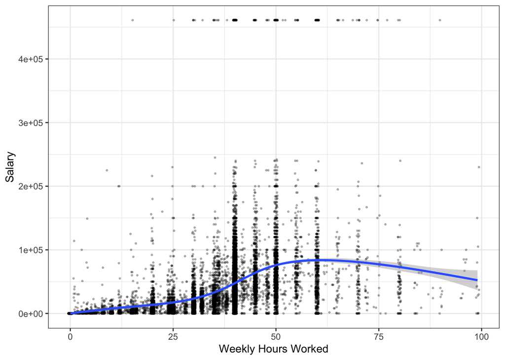

```r
ggplot(df, aes(x = weeklyhoursworked, y = salary)) +
    geom_point(size = 0.5, alpha = 0.25, position = "jitter") +
    geom_smooth() +
    theme_bw() +
    scale_x_continuous(name = "Weekly Hours Worked") +
    scale_y_continuous(name = "Salary")
```

Note the excess of the outliers.

#2. ANOVA Children v. Weekly Hours Worked

```r
anova0<-aov(weeklyhoursworked ~ children, data = df)
summary(anova0)
```

```
##                Df   Sum Sq Mean Sq F value Pr(>F)
## children        1   392887  392887     914 <2e-16 ***
## Residuals   28925 12432889     430
## ---
## Signif. codes:  0 '***' 0.001 '**' 0.01 '*' 0.05 '.' 0.1 ' ' 1
```

Salary v. Marital Status

```r
anova <- aov (salary ~ maritalstatus, data = df)
summary(anova)
```

```
##                  Df    Sum Sq   Mean Sq F value Pr(>F)
## maritalstatus     4 3.323e+12 8.306e+11     393 <2e-16 ***
## Residuals     28922 6.113e+13 2.114e+09
## ---
## Signif. codes:  0 '***' 0.001 '**' 0.01 '*' 0.05 '.' 0.1 ' ' 1
```

Difference Check for Salary v. Marital Status

```r
differences<-TukeyHSD(anova)
tribble<-as_tibble(cbind(pair = row.names(differences$maritalstatus),
                differences$maritalstatus))
tribble
```

```
## # A tibble: 10 x 5
##    pair                       diff         lwr         upr         `p adj`
##    <chr>                      <chr>        <chr>       <chr>       <chr>
##  1 Married-Divorced           3894.775208… 1453.99017… 6335.56023… 0.0001310457…
##  2 Never married or under 15… -18092.8276… -20525.105… -15660.549… 0
##  3 Separated-Divorced         -6307.55694… -12980.557… 365.443627… 0.0743548035…
##  4 Widowed-Divorced           -21342.6718… -25332.364… -17352.979… 0
##  5 Never married or under 15… -21987.6028… -23615.990… -20359.215… 0
##  6 Separated-Married          -10202.3321… -16626.085… -3778.5788… 0.0001436909…
##  7 Widowed-Married            -25237.4470… -28794.597… -21680.296… 0
##  8 Separated-Never married o… 11785.27071… 5364.74486… 18205.7965… 5.4825186832…
##  9 Widowed-Never married or … -3249.84418… -6801.1628… 301.474443… 0.0914284244…
## 10 Widowed-Separated          -15035.1148… -22192.266… -7877.9629… 1.0006494322…
```

Strong relationship between salary and marriage vs. divorce, salary and being unmarried vs. divorce, salary and widowing vs. divorce, salary and being unmarried vs. being married, salary and separation vs. marriage, and salary and being widowed vs. marriage.

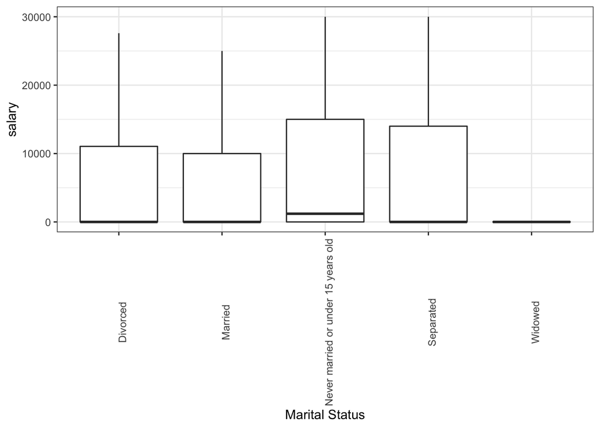

```r
ggplot(df, aes(x = maritalstatus, y = salary)) +
  geom_boxplot(outlier.shape=NA) +
  theme_bw() +
  theme(axis.text.x = element_text(angle = 90)) +
  scale_x_discrete(name = "Marital Status") +
  scale_y_continuous(name = "Salary",
                     breaks = seq(0, 105, by = 5),
                     labels = paste(prettyNum(seq(0, 105, by = 5),
                                              big.mark = ",")))+
  ylim(0,30000)
```

Interesting how all of the variation is in that 3rd quartile, but most people don’t make any money.

#3 Two-Sample T-Tests

Marriage, Divorce vs. Weekly Hours Worked

```r
difference1<-t.test(df$weeklyhoursworked ~ df$maritalstatus == "Divorced" ,
                    data = df )
difference1
```

```
##
##  Welch Two Sample t-test
##
## data:  df$weeklyhoursworked by df$maritalstatus == "Divorced"
## t = -13.963, df = 4335.7, p-value < 2.2e-16
## alternative hypothesis: true difference in means is not equal to 0
## 95 percent confidence interval:
##  -6.178306 -4.656996
## sample estimates:
## mean in group FALSE  mean in group TRUE
##            19.08191            24.49956
```

The link between weekly hours worked and divorce is apparently extremely significant, as the p-value is close to 0. Divorced individuals generally work more hours.

```r
difference2<-t.test(df$weeklyhoursworked ~ df$maritalstatus == "Married" ,
                    data = df )
difference2
```

```
##
##  Welch Two Sample t-test
##
## data:  df$weeklyhoursworked by df$maritalstatus == "Married"
## t = -35.442, df = 24081, p-value < 2.2e-16
## alternative hypothesis: true difference in means is not equal to 0
## 95 percent confidence interval:
##  -9.338549 -8.359760
## sample estimates:
## mean in group FALSE  mean in group TRUE
##            16.14768            24.99683
```

Funkily—ditto for married indidviduals vs non-married ones.

#4 Chi-Squared

```r
chi_sq <- chisq.test(df$maritalstatus, df$children)
chi_sq
```

```
##
##  Pearson's Chi-squared test
##
## data:  df$maritalstatus and df$children
## X-squared = 396.78, df = 8, p-value < 2.2e-16
```

```r
chi_sq$observed
```

```
##                                      df$children
## df$maritalstatus                         0    1    2
##   Divorced                            2756   21  634
##   Married                             9037  187 2456
##   Never married or under 15 years old 9256   99 2696
##   Separated                            259    6  129
##   Widowed                             1348    3   40
```

```r
chi_sq$expected
```

```
##                                      df$children
## df$maritalstatus                              0          1          2
##   Divorced                            2671.5393  37.261935  702.19881
##   Married                             9147.9269 127.592906 2404.48024
##   Never married or under 15 years old 9438.4988 131.645729 2480.85543
##   Separated                            308.5859   4.304076   81.11004
##   Widowed                             1089.4492  15.195354  286.35548
```